# Overfitting, crossvalidation, and sparsification

1/15/2022

## Using models to make predictions

“No scientific theory is worth anything unless it enables us to predict something which is actually going on. Until that is done, theories are a mere game of words, and not such a good game as poetry.” – J. B. S. Haldane

## Is having too many predictor variables a problem?

- The more predictor variables you add to a model the better it will seem to be at predicting the response variables in your dataset

## Is having too many predictor variables a problem?

- The more predictor variables you add to a model the better it will seem to be at predicting the response variables in your dataset
- Even if you are not giving it any additional useful information

## Is having too many predictor variables a problem?

- The more predictor variables you add to a model the better it will seem to be at predicting the response variables in your dataset
- Even if you are not giving it any additional useful information
- When you have as many predictor variables as observations it is possible to exactly match the data that you initially used to construct your model.

## Is having too many predictor variables a problem?

- The more predictor variables you add to a model the better it will seem to be at predicting the response variables in your dataset
- Even if you are not giving it any additional useful information
- When you have as many predictor variables as observations it is possible to exactly match the data that you initially used to construct your model.
- It’s possible to come up with a model that will give you precise predictions for the response variables included in your initial dataset

## Is having too many predictor variables a problem?

- The more predictor variables you add to a model the better it will seem to be at predicting the response variables in your dataset
- Even if you are not giving it any additional useful information
- When you have as many predictor variables as observations it is possible to exactly match the data that you initially used to construct your model.
- It’s possible to come up with a model that will give you precise predictions for the response variables included in your initial dataset
- But that is not generalizable to new data at all.

## Overfitting in real data

- Downloaded daily case counts from [the CDC](https://data.cdc.gov/Case-Surveillance/United-States-COVID-19-Cases-and-Deaths-by-State-o/9mfq-cb36).
- Subset the data to only include new case counts from the 1st and 15th of each month for each state
- Resulting in a data frame with 48 rows and 53 columns

```r
head(by_state[,1:17])
```

```
##            date AK  AL AR  AZ   CA  CO  CT  DC DE   FL  GA HI IA  ID   IL  IN
## 528  2020-02-01  0   0  0   0    0   0   0   0  0    0   0  0  0   0    0   0
## 406  2020-02-15  0   0  0   0    0   0   0   0  0    0   0  0  0   0    0   0
## 267  2020-03-01  0   0  0   0    0   0   0   0  0    0   0  0  0   0    1   0
## 696  2020-03-15  0  13  4   1   47  32  19  14  3   31  52  3  6   4   61   7
## 1143 2020-04-01 13 112 54 124 1223 385 429  91 37 1031 570 28 52 144  986 406
## 3290 2020-04-15  8 265 85 156 1171 316 766 139 62  900 686 11 96 101 1346 428
```

## Predicting COVID case count across states

Now let’s see how well the case counts in Oregon are predicted by other states, using only the 1st and 15th of each month:

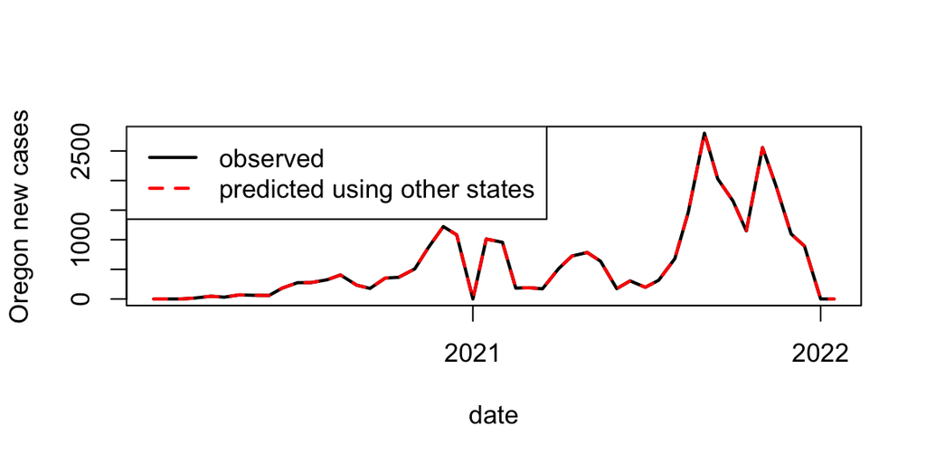

```r
OR_lm <- lm(OR ~ . - date, data=by_state)
plot(OR ~ date, data=by_state, type='l', lwd=2, ylab="Oregon new cases")
lines(by_state$date, predict(OR_lm), col='red', lty=2, lwd=2)
legend("topleft", lty=c(1, 2), col=c("black", "red"), lwd=c(2,2),
       legend=c("observed", "predicted using other states"))
```

## Overfitting: when you have too much information

## Overfitting: when you have too much information

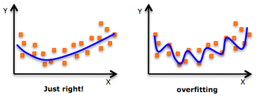

## Overfitting example

1. Simulate data with `y ~ a + b x[1] + c x[2]`
2. Add spurious variables
3. Fit a linear model and measure prediction error with different numbers of predictor variables.
4. Report the prediction error as a function of the number of variables.

## Simulating data: \(y = a + b_1 x_1 + b_2 x_2 + \epsilon\).

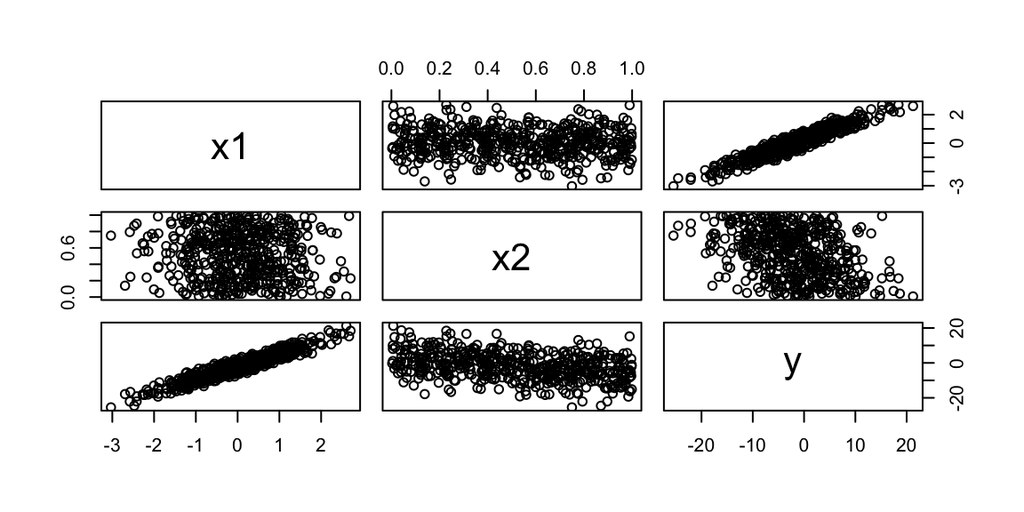

```r
N <- 500
df <- data.frame(x1 = rnorm(N), x2 = runif(N))
params <- list(intercept = 2.0, x1 = 7.0, x2 = -8.0, sigma = 1)
pred_y <- params$intercept + params$x1 * df$x1 + params$x2 * df$x2
df$y <- rnorm(N, mean=pred_y, sd=params$sigma)
pairs(df)
```

## Breaking down our simulating data code

```r
set.seed(23)
# Decide how many data points we want in our simulated dataset
N <- 500
```

```r
N <- 500
# Create a dataframe with values for our two predictor variables
df <- data.frame(x1 = rnorm(N), x2 = runif(N))
# rnorm samples from a normal distribution with mean 0
# runif samples from a uniform distribution between 0 and 1
head(df)
```

```
##      x1   x2
## 1  0.19 0.12
## 2 -0.43 0.02
## 3  0.91 0.74
## 4  1.79 0.57
## 5  1.00 0.93
## 6  1.11 0.67
```

```r
N <- 500
df <- data.frame(x1 = rnorm(N), x2 = runif(N))
# Create a list of parameters that we will use in our model
params <- list(intercept = 2.0, x1 = 7.0, x2 = -8.0, sigma = 1)
#x1 is the coefficient for the x1 variable
#x2 is the coefficient for the x2 variable
#sigma is the standard deviation of the random error in our model
params
```

```
## $intercept
## [1] 2
##
## $x1
## [1] 7
##
## $x2
## [1] -8
##
## $sigma
## [1] 1
```

```r
N <- 500
df <- data.frame(x1 = rnorm(N), x2 = runif(N))
params <- list(intercept = 2.0, x1 = 7.0, x2 = -8.0, sigma = 1)
# Write out our model which takes info from our df and the params list
pred_y <- params$intercept + params$x1 * df$x1 + params$x2 * df$x2
```

```r
N <- 500
df <- data.frame(x1 = rnorm(N), x2 = runif(N))
params <- list(intercept = 2.0, x1 = 7.0, x2 = -8.0, sigma = 1)
pred_y <- params$intercept + params$x1 * df$x1 + params$x2 * df$x2
# Simulate the values of our responsible variables
df$y <- rnorm(N, mean=pred_y, sd=params$sigma)
```

## Breaking down our simulating data code

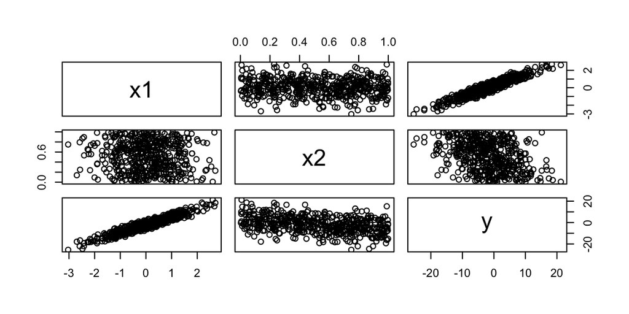

```r
N <- 500
df <- data.frame(x1 = rnorm(N), x2 = runif(N))
params <- list(intercept = 2.0, x1 = 7.0, x2 = -8.0, sigma = 1)
pred_y <- params$intercept + params$x1 * df$x1 + params$x2 * df$x2
df$y <- rnorm(N, mean=pred_y, sd=params$sigma)
# Look at the relationship between our variables
pairs(df)
```

## Overfitting excercise

1. Simulate data for this model: `y ~ a + b x[1] + c x[2]`
2. Add an additional 298 spurious variables to your data
3. Fit linear models with different numbers of predictor variables
4. Calculate the root mean squared error for the models you fit: `sqrt(mean(resid(lm)^2))`
5. Plot how prediction error changes with the number of predictor variables.

```r
N <- 500
df <- data.frame(x1 = rnorm(N), x2 = runif(N))
params <- list(intercept = 2.0, x1 = 7.0, x2 = -8.0, sigma = 1)
pred_y <- params$intercept + params$x1 * df$x1 + params$x2 * df$x2
df$y <- rnorm(N, mean=pred_y, sd=params$sigma)
```

## Add spurious variables

```r
max_M <- 300  # max number of spurious variables
noise_df <- matrix(rnorm(nrow(df) * (max_M-2)), nrow=nrow(df))
colnames(noise_df) <- paste0('z', 1:ncol(noise_df))
new_df <- cbind(df, noise_df)
head(new_df[,1:10])
```

```
##      x1   x2    y    z1     z2    z3     z4    z5    z6     z7
## 1  0.19 0.12  1.7 -0.28  0.360  0.80  0.287 -0.37 -2.33 -0.231
## 2 -0.43 0.02 -1.0 -0.88  0.476 -1.55  0.069 -0.72 -0.91 -1.352
## 3  0.91 0.74  2.2 -0.64  0.711  1.23 -1.238  1.08 -0.52 -0.745
## 4  1.79 0.57  9.6  0.15 -0.660  0.49  0.143  0.85  1.27 -0.073
## 5  1.00 0.93  2.0  0.55 -0.019  0.36  0.222 -1.72  0.54 -0.277
## 6  1.11 0.67  6.6  0.71 -0.542 -0.68 -1.409 -0.40  0.35  0.554
```

## Linear model and predictior error results

```r
all_results <- data.frame(m=floor(seq(from=2, to=max_M-1, length.out=40)), error=NA)
for (j in 1:nrow(all_results)) {
    m <- all_results$m[j]
    the_lm <- lm(y ~ ., data=new_df[,1:(m+1)])
    all_results$error[j] <- sqrt(mean(resid(the_lm)^2))
}
```

## Create a dataframe to store our results

```r
# Create a dataframe with an increasing number of values between 2 ansd 299
# We will fit linear models using these different numbers of variables
# Then store the error for each model in the data frame
# So that we have a calculated error for each number of variables
all_results <- data.frame(m=floor(seq(from=2, to=max_M-1, length.out=40)), error=NA)
head(all_results)
```

```
##    m error
## 1  2    NA
## 2  9    NA
## 3 17    NA
## 4 24    NA
## 5 32    NA
## 6 40    NA
```

## Fitting models with different numbers of variables

```r
# Then for the different numbers of variables in the m column of allresults
# We fit linear models and calculate the error
for (j in 1:nrow(all_results)) {
    m <- all_results$m[j]
    the_lm <- lm(y ~ ., data=new_df[,1:(m+1)])
    all_results$error[j] <- sqrt(mean(resid(the_lm)^2))
}
```

## Digging into this for loop

```r
# Set the number of predictors to include in our model
m <- all_results$m[2]
all_results$m[2]
```

```
## [1] 9
```

## Fitting linear models

```r
# Set the number of predictors to include in our model
m <- all_results$m[2]
# Fit our linear model using those number of predictor variables
the_lm <- lm(y ~ ., data=new_df[,1:(m+1)])
summary(the_lm)$coefficients
```

```
##             Estimate Std. Error t value Pr(>|t|)
## (Intercept)    2.015      0.090   22.38  6.1e-77
## x1             6.998      0.043  161.65  0.0e+00
## x2            -8.054      0.152  -53.02 4.0e-205
## z1            -0.025      0.041   -0.60  5.5e-01
## z2             0.013      0.046    0.28  7.8e-01
## z3            -0.041      0.044   -0.94  3.5e-01
## z4            -0.015      0.043   -0.35  7.3e-01
## z5            -0.069      0.043   -1.60  1.1e-01
## z6            -0.018      0.045   -0.39  6.9e-01
## z7             0.048      0.043    1.11  2.7e-01
```

## Calculating error for a model

```r
# Set the number of predictors to include in our model
m <- all_results$m[2]
# Fit our linear model using those number of predictor variables
the_lm <- lm(y ~ ., data=new_df[,1:(m+1)])
# Calculate the square root of the mean squared residuals
all_results$error[j] <- sqrt(mean(resid(the_lm)^2))
```

\[\begin{aligned} S = \sqrt{\frac{1}{M} \sum_{k=1}^M (\hat y_i - y_i)^2} \end{aligned}\]

## Linear model and predictor error results

```r
all_results <- data.frame(m=floor(seq(from=2, to=max_M-1, length.out=40)), error=NA)
for (j in 1:nrow(all_results)) {
    m <- all_results$m[j]
    the_lm <- lm(y ~ ., data=new_df[,1:(m+1)])
    all_results$error[j] <- sqrt(mean(resid(the_lm)^2))
}
```

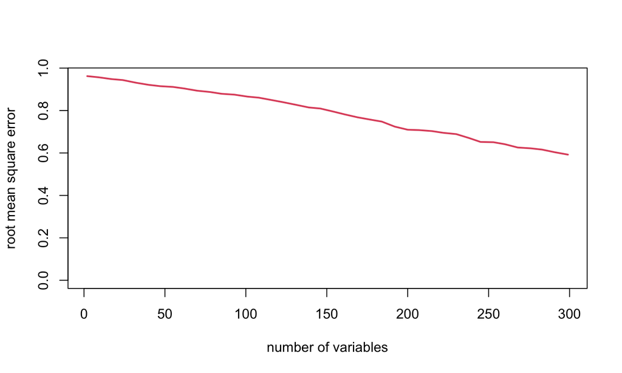

```r
plot(all_results$m, all_results$error, type='l', col=2, lwd=2,
     xlab='number of variables', ylab='root mean square error',
     ylim=range(all_results$error, 0))
```

## Out-of-sample prediction

To test predictive ability (and diagnose overfitting!):

## Out-of-sample prediction

To test predictive ability (and diagnose overfitting!):

1. Split the data into *test* and *training* pieces.

## Out-of-sample prediction

To test predictive ability (and diagnose overfitting!):

1. Split the data into *test* and *training* pieces.
2. Fit the model using the training data.

## Out-of-sample prediction

To test predictive ability (and diagnose overfitting!):

1. Split the data into *test* and *training* pieces.
2. Fit the model using the training data.
3. See how well it predicts the test data.

## Crossvalidation

## Crossvalidation example

1. Simulate data with `y ~ a + b x[1] + c x[2]`, and fit a linear model.
2. Measure in-sample and out-of-sample prediction error.
3. Add spurious variables, and report the above as a function of number of variables.

## Crossvalidation plan

1. Put aside 20% of the data for *testing*.
2. Refit the model.

## Crossvalidation plan

1. Put aside 20% of the data for *testing*.
2. Refit the model.
3. Predict the test data;
4. Compute test error square root of the mean squared difference between the actual and predicted values

## Crossvalidation plan

1. Put aside 20% of the data for *testing*.
2. Refit the model.
3. Predict the test data;
4. Compute test error square root of the mean squared difference between the actual and predicted values
5. Repeat for the other four 20%s.
6. Compare

## Crossvalidation Example

1. Randomly put aside 20% of your data for testing
2. Fit a linear model to the remaining 80% of your data
3. Compute the training (80%) error: `sqrt(mean(resid(lm)^2))`
4. And the test (20%) error: `sqrt(mean(("actual y" - "predicted y")^2))`
5. Perform five-fold crossvalidation (repeat steps 1 to 3 four more times)
6. Compare the prediction error for your test and training data
7. Repeat this process this with different numbers of predictors
8. Plot how the test and training errors differ with the number of predictors

## Crossvalidation error function

```r
kfold <- function (K, df) {
    Kfold <- sample(rep(1:K, nrow(df)/K))
    results <- data.frame(test_error=rep(NA, K), train_error=rep(NA, K))
    for (k in 1:K) {
        the_lm <- lm(y ~ ., data=df, subset=(Kfold != k))
        results$train_error[k] <- sqrt(mean(resid(the_lm)^2))
        test_y <- df$y[Kfold == k]
        results$test_error[k] <- sqrt(mean(
                       (test_y - predict(the_lm, newdata=subset(df, Kfold==k)))^2 ))
    }
    return(results)
}
```

```r
#Assign every row of our dataframe a random number from 1 to the number of folds
df <- new_df[,1:(9+1)]
K <- 5
Kfold <- sample(rep(1:K, nrow(df)/K))
Kfold
```

```
##   [1] 4 5 5 2 4 4 1 2 2 1 2 2 1 1 5 2 1 2 5 2 5 2 2 4 4 1 4 3 4 3 3 3 3 1 4 3 1
##  [38] 3 3 4 5 5 1 2 1 1 1 3 3 2 2 3 5 3 1 4 3 4 3 5 3 4 5 1 1 1 3 2 3 2 5 2 3 3
##  [75] 3 2 2 5 2 4 3 5 3 5 3 5 4 2 4 3 5 1 5 2 2 5 4 4 1 3 4 2 1 5 1 3 2 4 5 2 1
## [112] 5 4 3 1 1 2 1 2 5 1 2 1 5 2 5 1 3 2 5 2 5 2 4 5 1 4 1 2 2 5 5 5 4 4 2 5 5
## [149] 1 4 3 3 3 2 2 4 1 4 2 1 2 3 4 4 4 3 2 1 5 5 1 3 3 4 1 4 5 4 5 5 2 5 4 4 2
## [186] 3 5 3 2 5 5 4 4 1 2 3 4 5 2 4 1 4 5 3 3 1 3 2 2 2 5 1 5 3 3 4 3 5 2 1 4 2
## [223] 5 3 5 5 3 1 1 2 2 4 4 3 5 5 4 2 2 5 3 4 2 1 5 4 3 2 2 3 5 2 5 5 1 4 3 2 3
## [260] 1 1 3 3 4 4 1 4 4 4 3 5 2 2 5 3 1 5 3 5 5 4 5 4 1 4 1 5 1 2 3 4 1 5 1 4 2
## [297] 2 3 3 1 5 4 5 5 4 2 3 3 4 2 2 4 1 1 5 4 1 4 2 4 1 3 2 3 3 2 1 2 5 5 3 4 5
## [334] 2 1 1 1 4 3 5 1 4 2 3 4 2 1 3 1 5 2 3 3 3 1 2 5 2 1 1 1 4 4 2 5 1 4 5 5 4
## [371] 1 1 1 4 3 5 3 2 3 1 3 1 4 4 5 2 2 1 2 1 4 4 2 2 5 3 1 1 1 3 3 4 2 4 1 5 1
## [408] 3 1 4 3 4 2 1 1 4 3 5 4 2 5 1 3 3 5 3 5 4 4 4 3 5 1 5 3 2 2 3 3 1 2 4 3 5
## [445] 1 4 3 2 5 2 1 5 4 2 3 5 2 3 3 5 5 4 4 1 2 2 5 2 4 1 5 4 1 2 4 3 2 4 3 1 5
## [482] 1 5 2 4 1 3 4 1 1 3 4 5 5 3 3 5 4 1 1
```

## Dissecting this function

```r
# Make an empty dataframe to store our test and training error
df <- new_df[,1:(9+1)]
K <- 5
Kfold <- sample(rep(1:K, nrow(df)/K))
results <- data.frame(test_error=rep(NA, 5), train_error=rep(NA, 5))
results
```

```
##   test_error train_error
## 1         NA          NA
## 2         NA          NA
## 3         NA          NA
## 4         NA          NA
## 5         NA          NA
```

## Dissecting the for loop in our function

```r
# Fit a linear model with 80% of the data for each fold
    for (k in 1:K) {
        the_lm <- lm(y ~ ., data=df, subset=(Kfold != k))
        results$train_error[k] <- sqrt(mean(resid(the_lm)^2))
        test_y <- df$y[Kfold == k]
        results$test_error[k] <- sqrt(mean(
                       (test_y - predict(the_lm, newdata=subset(df, Kfold==k)))^2 ))
    }
```

## Dissecting the for loop in our function

```r
# By specifying Kfold != k we only use rows with a label that is not equal to k
# Each time we fit a linear model we put aside 20% of the data for testing
df <- new_df[,1:(9+1)]
K <- 5
Kfold <- sample(rep(1:K, nrow(df)/K))
results <- data.frame(test_error=rep(NA, 5), train_error=rep(NA, 5))
the_lm <- lm(y ~ ., data=df)
the_lm$df.residual
```

```
## [1] 490
```

```r
the_lm <- lm(y ~ ., data=df, subset=(Kfold != 1))
the_lm$df.residual
```

```
## [1] 390
```

## Dissecting the for loop in our function

```r
df <- new_df[,1:(9+1)]
K <- 5
Kfold <- sample(rep(1:K, nrow(df)/K))
results <- data.frame(test_error=rep(NA, 5), train_error=rep(NA, 5))
results <- data.frame(test_error=rep(NA, 5), train_error=rep(NA, 5))
    for (k in 1:K) {
        the_lm <- lm(y ~ ., data=df, subset=(Kfold != k))
        # Calculate the training error for the models we fit during each fold
        results$train_error[k] <- sqrt(mean(resid(the_lm)^2))
        # Create a vector with our test response variable values
        test_y <- df$y[Kfold == k]
        # Calculate the test error for the models we fit during each fold
        # Store these values in the results dataframe with the training error values
        results$test_error[k] <- sqrt(mean(
                       (test_y - predict(the_lm, newdata=subset(df, Kfold==k)))^2 ))
    }
```

## Crossvalidation error function

```r
kfold <- function (K, df) {
    Kfold <- sample(rep(1:K, nrow(df)/K))
    results <- data.frame(test_error=rep(NA, K), train_error=rep(NA, K))
    for (k in 1:K) {
        the_lm <- lm(y ~ ., data=df, subset=(Kfold != k))
        results$train_error[k] <- sqrt(mean(resid(the_lm)^2))
        test_y <- df$y[Kfold == k]
        results$test_error[k] <- sqrt(mean(
                       (test_y - predict(the_lm, newdata=subset(df, Kfold==k)))^2 ))
    }
    return(results)
}
```

## Perform crossvalidation

```r
all_results <- data.frame(m=floor(seq(from=2, to=max_M-1, length.out=40)),
                          test_error=NA, train_error=NA)
for (j in 1:nrow(all_results)) {
    m <- all_results$m[j]
    all_results[j,2:3] <- colMeans(kfold(K=5, new_df[,1:(m+1)]))
}
```

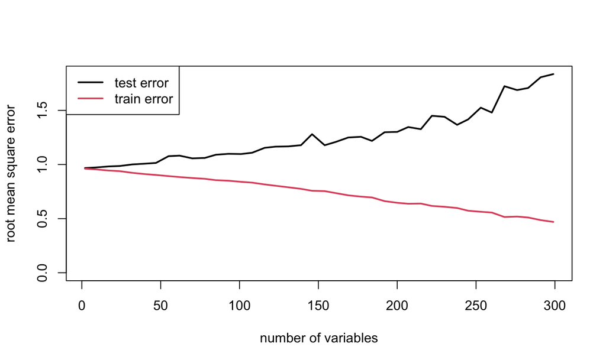

```r
plot(all_results$m, all_results$test_error, type='l', lwd=2,
     xlab='number of variables', ylab='root mean square error',
     ylim=range(all_results[,2:3], 0))
lines(all_results$m, all_results$train_error, col=2, lwd=2)
legend("topleft", lty=1, col=1:2, lwd=2, legend=paste(c("test", "train"), "error"))
```